# Forecasting series temporales incompletas

**Joaquin Amat Rodrigo, Javier Escobar Ortiz**

*Noviembre, 2022 (última actualización Noviembre 2024)*

Más sobre forecasting en: [**cienciadedatos.net**](https://cienciadedatos.net)

- [Forecasting series temporales con machine learning](https://www.cienciadedatos.net/documentos/py27-forecasting-series-temporales-python-scikitlearn.html)
- [Modelos ARIMA y SARIMAX](https://cienciadedatos.net/documentos/py51-modelos-arima-sarimax-python.html)
- [Forecasting series temporales con gradient boosting: XGBoost, LightGBM y CatBoost](https://www.cienciadedatos.net/documentos/py39-forecasting-series-temporales-con-skforecast-xgboost-lightgbm-catboost.html)
- [Forecasting series temporales con XGBoost](https://www.cienciadedatos.net/documentos/py56-forecasting-series-temporales-con-xgboost.html)
- [Global Forecasting: Multi-series forecasting](https://www.cienciadedatos.net/documentos/py44-multi-series-forecasting-skforecast-espa%C3%B1ol.html)
- [Forecasting de la demanda eléctrica con machine learning](https://www.cienciadedatos.net/documentos/py29-forecasting-demanda-energia-electrica-python.html)
- [Modelos de forecasting globales: Análisis comparativo de modelos de una y múltiples series](https://www.cienciadedatos.net/documentos/py53-modelos-forecasting-globales.html)
- [Forecasting con deep learning](https://cienciadedatos.net/documentos/py54-forecasting-con-deep-learning)
- [Forecasting de visitas a página web con machine learning](https://www.cienciadedatos.net/documentos/py37-forecasting-visitas-web-machine-learning.html)
- [Forecasting del precio de Bitcoin](https://www.cienciadedatos.net/documentos/py41-forecasting-criptomoneda-bitcoin-machine-learning-python.html)
- [Forecasting probabilístico](https://cienciadedatos.net/documentos/py42-forecasting-probabilistico.html)
- [Forecasting de demanda intermitente](https://www.cienciadedatos.net/documentos/py48-forecasting-demanda-intermitente.html)
- [Reducir el impacto del Covid en modelos de forecasting](https://www.cienciadedatos.net/documentos/py45-weighted-time-series-forecasting-es.html)
- [Modelar series temporales con tendencia utilizando modelos de árboles](https://www.cienciadedatos.net/documentos/py49-modelar-tendencia-en-series-temporales-modelos-de-arboles.html)

[figure not shown]

## Series temporales con valores faltantes

En muchos casos reales de forecasting, aunque se disponga de datos históricos, es habitual que las series temporales estén incompletas. La presencia de valores faltantes (*missing*) en los datos es un problema importante, ya que la mayoría de los algoritmos de forecasting requieren que las series temporales estén completas para poder entrenar un modelo.

Una estrategia comúnmente empleada para evitar este problema consiste en imputar los valores que faltan antes de entrenar el modelo, por ejemplo, utilizando una media móvil. Sin embargo, la calidad de las imputaciones puede no ser buena, lo que perjudica el entrenamiento del modelo. Una forma de mejorar la estrategia de imputación es combinarla con [weighted time series forecasting](https://skforecast.org/latest/user_guides/weighted-time-series-forecasting). Esta última consiste en reducir el peso de las observaciones imputadas y, por tanto, su influencia durante el entrenamiento del modelo.

Este documento muestra dos ejemplos de cómo **skforecast** facilita la aplicación de esta estrategia.

## Librarías

```python
# Manipulación de datos
# ==============================================================================
import numpy as np
import pandas as pd
from skforecast.datasets import fetch_dataset

# Gráficos
# ==============================================================================
import matplotlib.pyplot as plt
from skforecast.plot import set_dark_theme

# Modelado y Forecasting
# ==============================================================================
import sklearn
import skforecast
from lightgbm import LGBMRegressor
from skforecast.recursive import ForecasterRecursive
from skforecast.model_selection import TimeSeriesFold
from skforecast.model_selection import backtesting_forecaster

# Warnings
# ==============================================================================
import warnings

color = '\033[1m\033[38;5;208m'
print(f"{color}Version skforecast: {skforecast.__version__}")
print(f"{color}Version scikit-learn: {sklearn.__version__}")
print(f"{color}Version pandas: {pd.__version__}")
print(f"{color}Version numpy: {np.__version__}")
```

```
Version skforecast: 0.14.0
Version scikit-learn: 1.5.1
Version pandas: 2.2.3
Version numpy: 2.0.2
```

## Datos

```python
# Descarga de datos
# ==============================================================================
data = fetch_dataset('bicimad')
data
```

```
bicimad
-------
This dataset contains the daily users of the bicycle rental service (BiciMad) in
the city of Madrid (Spain) from 2014-06-23 to 2022-09-30.
The original data was obtained from: Portal de datos abiertos del Ayuntamiento
de Madrid https://datos.madrid.es/portal/site/egob
Shape of the dataset: (3022, 1)
```

| date | users |
| --- | --- |
| 2014-06-23 | 99 |
| 2014-06-24 | 72 |
| 2014-06-25 | 119 |
| 2014-06-26 | 135 |
| 2014-06-27 | 149 |
| ... | ... |
| 2022-09-26 | 12340 |
| 2022-09-27 | 13888 |
| 2022-09-28 | 14239 |
| 2022-09-29 | 11574 |
| 2022-09-30 | 12957 |

3022 rows × 1 columns

```python
# Crear periodos sin datos (gaps) sobreescibiendo los valores con NaN
# ==============================================================================
gaps = [
    ['2020-09-01', '2020-10-10'],
    ['2020-11-08', '2020-12-15'],
]

for gap in gaps:
    data.loc[gap[0]:gap[1]] = np.nan
```

```python
# División datos en train-test
# ==============================================================================
data = data.loc['2020-06-01':'2021-06-01'].copy()
end_train = '2021-03-01'
data_train = data.loc[: end_train, :]
data_test  = data.loc[end_train:, :]

print(f"Fechas train : {data_train.index.min()} --- {data_train.index.max()}  (n={len(data_train)})")
print(f"Fechas test  : {data_test.index.min()} --- {data_test.index.max()}  (n={len(data_test)})")
```

```
Fechas train : 2020-06-01 00:00:00 --- 2021-03-01 00:00:00  (n=274)
Fechas test  : 2021-03-01 00:00:00 --- 2021-06-01 00:00:00  (n=93)
```

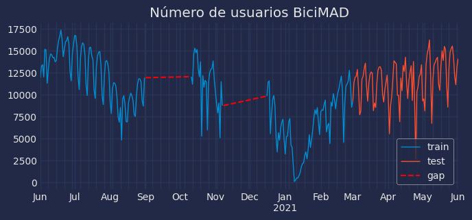

```python
# Gráfico con periodos sin datos
# ==============================================================================
set_dark_theme()
fig, ax = plt.subplots(figsize=(7, 3))
data_train.users.plot(ax=ax, label='train', linewidth=1)
data_test.users.plot(ax=ax, label='test', linewidth=1)

for gap in gaps:
    ax.plot(
        [pd.to_datetime(gap[0]), pd.to_datetime(gap[1])],
        [data.users[pd.to_datetime(gap[0]) - pd.Timedelta(days=1)],
         data.users[pd.to_datetime(gap[1]) + pd.Timedelta(days=1)]],
        color = 'red',
        linestyle = '--',
        label = 'gap'
        )

ax.set_title('Número de usuarios BiciMAD')
ax.set_xlabel('')
handles, labels = plt.gca().get_legend_handles_labels()
by_label = dict(zip(labels, handles))
ax.legend(by_label.values(), by_label.keys(), loc='lower right');
```

## Imputación de valores faltantes

```python
# Imputación de valores mediante interpolación lineal
# ======================================================================================
data['users_imputed'] = data['users'].interpolate(method='linear')
data_train = data.loc[: end_train, :]
data_test  = data.loc[end_train:, :]
```

## Modelo con valores imputados

```python
# Crear forecaster (ForecasterAutoreg) con 14 lags
# ==============================================================================
forecaster = ForecasterRecursive(
                 regressor = LGBMRegressor(random_state=123, verbose=-1),
                 lags      = 14
             )

# Backtesting: se predicen en cada iteración 7 días
# ==============================================================================
cv = TimeSeriesFold(
        steps              = 7,
        initial_train_size = len(data.loc[:end_train]),
        refit              = True,
        fixed_train_size   = False
    )
metrica, predicciones = backtesting_forecaster(
                            forecaster = forecaster,
                            y          = data.users_imputed,
                            cv         = cv,
                            metric     = 'mean_absolute_error',
                            verbose    = False
                        )
display(metrica)
predicciones.head(4)
```

|  | mean_absolute_error |
| --- | --- |
| 0 | 2151.339364 |

|  | pred |
| --- | --- |
| 2021-03-02 | 9679.561409 |
| 2021-03-03 | 10556.841280 |
| 2021-03-04 | 8922.423792 |
| 2021-03-05 | 8874.277159 |

## Dar peso de cero a los valores imputados

Para minimizar la influencia en el modelo de los valores imputados, se define una función que crea pesos acorde a las siguientes reglas:

- Peso de 0 si la fecha del índice al periodo imputado o está a ménos de 14 días de él.
- Peso de 1 en caso contrario.

Si una observación tiene un peso de 0, no influye en el entrenamiento del modelo.

**✎ Nota**

Los valores imputados no deben participar en el proceso de entrenamiento ni como *target* ni como predictor (lags). Por lo tanto, también deben excluirse los valores dentro de una ventana de tamaño tan grande como los lags utilizados.

```python
# Función para asignar pesos a las observaciones
# ==============================================================================
def custom_weights(index):
    """
    Devuelve 0 si el índice se encuentra en algún gap.
    """
    gaps = [
        ['2020-09-01', '2020-10-10'],
        ['2020-11-08', '2020-12-15'],
    ]

    missing_dates = [pd.date_range(
                        start = pd.to_datetime(gap[0]) + pd.Timedelta('14d'),
                        end   = pd.to_datetime(gap[1]) + pd.Timedelta('14d'),
                        freq  = 'D'
                    ) for gap in gaps]
    missing_dates = pd.DatetimeIndex(np.concatenate(missing_dates))
    weights = np.where(index.isin(missing_dates), 0, 1)

    return weights
```

Se entrena de nuevo un `ForecasterAutoreg` pero esta vez incluyendo la función `custom_weights`.

```python
# Crear forecaster (ForecasterAutoreg) con 14 lags
# ==============================================================================
forecaster = ForecasterRecursive(
                 regressor   = LGBMRegressor(random_state=123, verbose=-1),
                 lags        = 14,
                 weight_func = custom_weights
             )

# Backtesting: se predicen en cada iteración 7 días
# ==============================================================================
metrica, predicciones = backtesting_forecaster(
                            forecaster = forecaster,
                            y          = data.users_imputed,
                            cv         = cv,
                            metric     = 'mean_absolute_error',
                            verbose    = False
                        )
display(metrica)
predicciones.head(4)
```

|  | mean_absolute_error |
| --- | --- |
| 0 | 1904.830714 |

|  | pred |
| --- | --- |
| 2021-03-02 | 10524.159747 |
| 2021-03-03 | 10087.283682 |
| 2021-03-04 | 8882.926166 |
| 2021-03-05 | 9474.810215 |

Asignando un peso de 0 a los valores imputados (excluyéndolos del entrenamiento del modelo) se mejora el rendimiento del forecasting.

## Información de sesión

```python
import session_info
session_info.show(html=False)
```

```
-----
lightgbm            4.5.0
matplotlib          3.9.2
numpy               2.0.2
pandas              2.2.3
session_info        1.0.0
skforecast          0.14.0
sklearn             1.5.1
-----
IPython             8.27.0
jupyter_client      8.6.3
jupyter_core        5.7.2
notebook            6.4.12
-----
Python 3.12.5 | packaged by Anaconda, Inc. | (main, Sep 12 2024, 18:27:27) [GCC 11.2.0]
Linux-5.15.0-1071-aws-x86_64-with-glibc2.31
-----
Session information updated at 2024-11-04 16:08
```

## Instrucciones para citar

**¿Cómo citar este documento?**

Si utilizas este documento o alguna parte de él, te agradecemos que lo cites. ¡Muchas gracias!

Forecasting series temporales incompletas por Joaquín Amat Rodrigo y Javier Escobar Ortiz, disponible bajo una licencia Attribution-NonCommercial-ShareAlike 4.0 International (CC BY-NC-SA 4.0 DEED) en https://www.cienciadedatos.net/documentos/py36-forecasting-series-temporales-incompletas.html

**¿Cómo citar skforecast?**

Si utilizas skforecast en tu investigación o publicación, te lo agradeceríamos mucho que lo cites. ¡Muchas gracias!

Zenodo:

Amat Rodrigo, Joaquin, & Escobar Ortiz, Javier. (2024). skforecast (v0.14.0). Zenodo. https://doi.org/10.5281/zenodo.8382788

APA:

Amat Rodrigo, J., & Escobar Ortiz, J. (2024). skforecast (Version 0.14.0) [Computer software]. https://doi.org/10.5281/zenodo.8382788

BibTeX:

@software{skforecast, author = {Amat Rodrigo, Joaquin and Escobar Ortiz, Javier}, title = {skforecast}, version = {0.14.0}, month = {11}, year = {2024}, license = {BSD-3-Clause}, url = {https://skforecast.org/}, doi = {10.5281/zenodo.8382788} }

Este documento creado por Joaquín Amat Rodrigo y Javier Escobar Ortiz tiene licencia [Attribution-NonCommercial-ShareAlike 4.0 International](https://creativecommons.org/licenses/by-nc-sa/4.0/).